# Bayesian regression to predict audience score for a movie

## Setup

### Load packages

```r
library(ggplot2)
library(dplyr)
library(statsr)
library(BAS)
library(broom)
```

### Load data

```r
load("movies.Rdata")
```

## Part 1: Data

The dataset provided is data regarding a sample of movies of size 651 produced and released before 2016. We can assume random sampling is done as is mentioned in the description of the dataset. This dataset cannot be generalized for all movies as regional movies do not seem to be included in this list. However, the dataset can possibly be generalized for Hollywood movies. Any conclusions made from this dataset cannot prove causality as this is only an observational study as no experiment is being conducted.

## Part 2: Data manipulation

In this section,we will be adding five new columns to the existing dataset based on the existing columns which will provide value in our regression analysis. The new columns are: ‘feature_film’, ‘drama’,‘mpaa_rating_R’,‘oscar_season’,‘summer_season’

1. Feature_film: This column will tell if the film is a feature film or not.

```r
movies$feature_film<-ifelse(movies$title_type=="Feature Film","Yes","No")
```

2.Drama: This column will tell whether the genre of the movie is drama or not.

```r
movies$drama<-ifelse(movies$genre=="Drama","Yes","No")
```

3.Mpaa_rating_R : This colun will tell whether the film is rated 18+ or not.

```r
movies$mpaa_rating_R<-ifelse(movies$mpaa_rating=="R","Yes","No")
```

4. Oscar_season : This column will tell whether or not the movie was released in the oscar season of November, October or December.

```r
movies$oscar_season<-ifelse(movies$thtr_rel_month %in% c(10,11,12),"Yes","No")
```

5. Summer_season : This column will tell whether or not the movie was released in the summer season of May,June, July or August.

```r
movies$summer_season<-ifelse(movies$thtr_rel_month %in% c(5,6,7,8),"Yes","No")
```

And finally, we will remove the columns we dont intend to conduct EDA or use for the modelling.

```r
movie<-movies%>%
  select(feature_film,drama,runtime,mpaa_rating_R,thtr_rel_year,oscar_season,summer_season,imdb_rating,imdb_num_votes,critics_score,best_pic_nom,best_pic_win,best_actor_win,best_actress_win,best_dir_win,top200_box,audience_score)
```

Now our dataset which we will be using is complete. * * *

## Part 3: Exploratory data analysis

In this section we will take a look at the relationship between our response variable ‘Audience_score’ and the variables we have chosen and formed in the dataset. Let’s take a look at the summary statistics of our data.

```r
summary(movie)
```

```
##  feature_film          drama              runtime      mpaa_rating_R
##  Length:651         Length:651         Min.   : 39.0   Length:651
##  Class :character   Class :character   1st Qu.: 92.0   Class :character
##  Mode  :character   Mode  :character   Median :103.0   Mode  :character
##                                        Mean   :105.8
##                                        3rd Qu.:115.8
##                                        Max.   :267.0
##                                        NA's   :1
##  thtr_rel_year  oscar_season       summer_season       imdb_rating
##  Min.   :1970   Length:651         Length:651         Min.   :1.900
##  1st Qu.:1990   Class :character   Class :character   1st Qu.:5.900
##  Median :2000   Mode  :character   Mode  :character   Median :6.600
##  Mean   :1998                                         Mean   :6.493
##  3rd Qu.:2007                                         3rd Qu.:7.300
##  Max.   :2014                                         Max.   :9.000
##
##  imdb_num_votes   critics_score    best_pic_nom best_pic_win
##  Min.   :   180   Min.   :  1.00   no :629      no :644
##  1st Qu.:  4546   1st Qu.: 33.00   yes: 22      yes:  7
##  Median : 15116   Median : 61.00
##  Mean   : 57533   Mean   : 57.69
##  3rd Qu.: 58301   3rd Qu.: 83.00
##  Max.   :893008   Max.   :100.00
##
##  best_actor_win best_actress_win best_dir_win top200_box audience_score
##  no :558        no :579          no :608      no :636    Min.   :11.00
##  yes: 93        yes: 72          yes: 43      yes: 15    1st Qu.:46.00
##                                                          Median :65.00
##                                                          Mean   :62.36
##                                                          3rd Qu.:80.00
##                                                          Max.   :97.00
##
```

We can see that the dataset has 6 numerical variables and 11 categoricl variables and seems to be a fairly complete dataset with the exception of one row which has a value of runtime missing. For the sake of convinience we will remove this row.

```r
movie<-movie[!is.na(movie$runtime),]
```

Let us take a look at some of the relationships. First, let us see if there is a relationship between the audience score and the movie being a feature film.

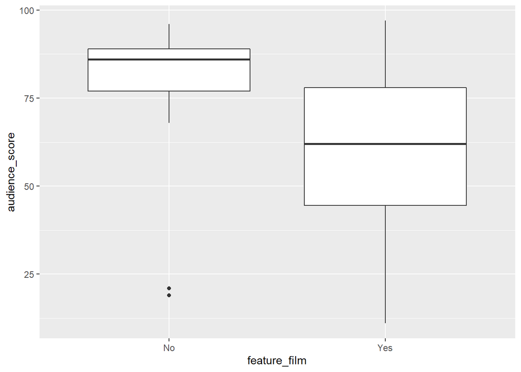

```r
ggplot(data=movie, aes(x=feature_film, y=audience_score))+geom_boxplot()
```

It is quite interesting that films that are not feature films tend to get much higher score on average compared to those which are not. The range is also lower on the movies which are not feature films so it is quite clear that there is a relation between whether films are feature films or not.

Next we will take a look at the relationship between the audience score and the movie being a drama.

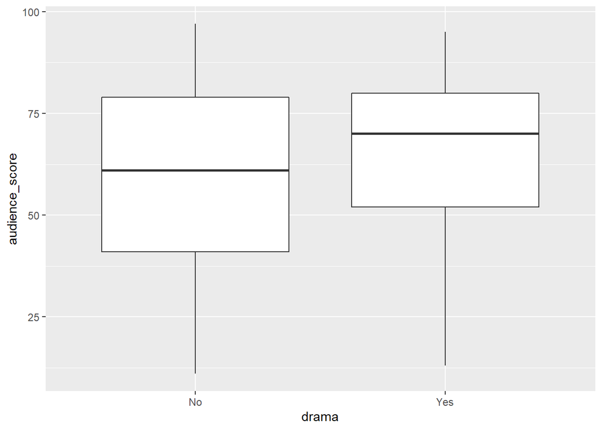

```r
ggplot(data=movie, aes(x=drama, y=audience_score))+geom_boxplot()
```

Here we can see that dramas tend to get a higher audience score compared to movies that aren’t.

Next we will take a look at the relationship between the audience score and the movie being R rated.

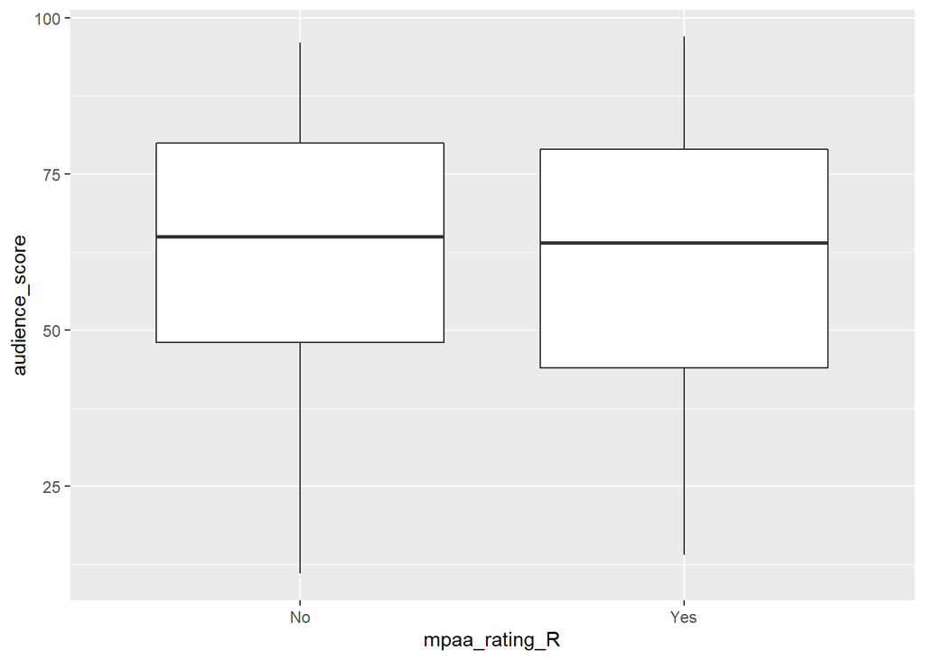

```r
ggplot(data=movie, aes(x=mpaa_rating_R, y=audience_score))+geom_boxplot()
```

Here, we can see that the ratin of the movie doesn’t seem to have much influence on the audience score. hence we can remove this from our dataset.

```r
movie<-movie%>%
  select(- mpaa_rating_R)
```

Next we will take a look at the relationship between the audience score and the movie being released during the oscar season.

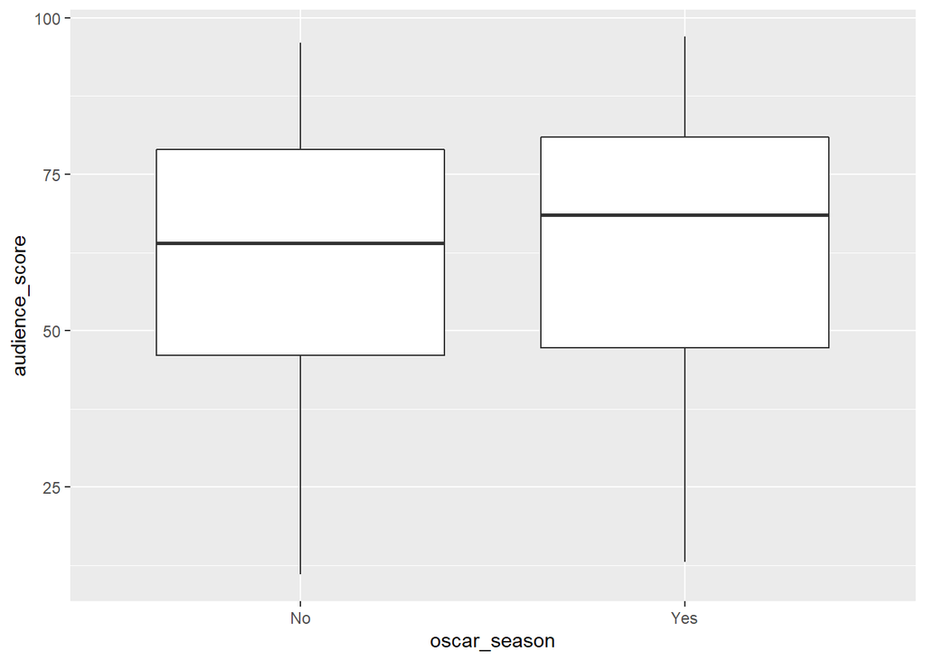

```r
ggplot(data=movie, aes(x=oscar_season, y=audience_score))+geom_boxplot()
```

Next we will take a look at the relationship between the audience score and the movie being released during summer.

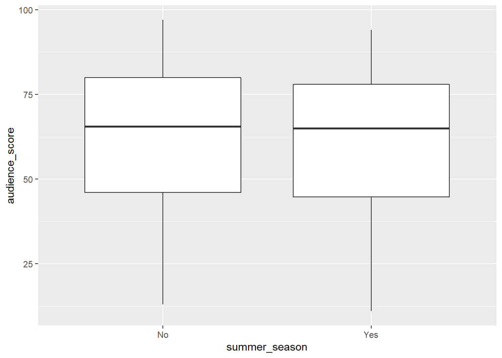

```r
ggplot(data=movie, aes(x=summer_season, y=audience_score))+geom_boxplot()
```

Here however, there does not seem to be much variation in the ratings whether the movie was released during the summer or not. Hence ,we can eliminate it from our regression analysis.

```r
movie<-movie%>%
  select(- summer_season)
```

We will now move on to the modelling section of our problem. * * *

## Part 4: Modeling

For our modelling and model selection we will use BIC as model selection criterion with model reference as uniform distribution, we will also using Bayesion model averaging. We will the BAS package to construct and run our model.

We start by applying BMA to the audience data using all potential predictors and take a look at he PIPs of the various coefficients.

```r
# Fit the model using Bayesian linear regression, `bas.lm` function in the `BAS` package
bma_audience_score <- bas.lm(audience_score ~ . -audience_score, data = movie,
                   prior = "BIC",
                   modelprior = uniform())

# Print out the marginal posterior inclusion probabilities for each variable
bma_audience_score
```

```
##
## Call:
## bas.lm(formula = audience_score ~ . - audience_score, data = movie,
##     prior = "BIC", modelprior = uniform())
##
##
##  Marginal Posterior Inclusion Probabilities:
##           Intercept      feature_filmYes             dramaYes
##             1.00000              0.06844              0.04178
##             runtime        thtr_rel_year      oscar_seasonYes
##             0.47251              0.09091              0.07718
##         imdb_rating       imdb_num_votes        critics_score
##             1.00000              0.05707              0.89516
##     best_pic_nomyes      best_pic_winyes    best_actor_winyes
##             0.13067              0.03984              0.14398
## best_actress_winyes      best_dir_winyes        top200_boxyes
##             0.13947              0.06785              0.04875
```

```r
# Top 5 most probably models
summary(bma_audience_score)
```

```
##                     P(B != 0 | Y)    model 1       model 2       model 3
## Intercept              1.00000000     1.0000     1.0000000     1.0000000
## feature_filmYes        0.06844202     0.0000     0.0000000     0.0000000
## dramaYes               0.04177629     0.0000     0.0000000     0.0000000
## runtime                0.47250942     1.0000     0.0000000     0.0000000
## thtr_rel_year          0.09091245     0.0000     0.0000000     0.0000000
## oscar_seasonYes        0.07717793     0.0000     0.0000000     0.0000000
## imdb_rating            1.00000000     1.0000     1.0000000     1.0000000
## imdb_num_votes         0.05707158     0.0000     0.0000000     0.0000000
## critics_score          0.89515674     1.0000     1.0000000     1.0000000
## best_pic_nomyes        0.13067260     0.0000     0.0000000     0.0000000
## best_pic_winyes        0.03984414     0.0000     0.0000000     0.0000000
## best_actor_winyes      0.14398493     0.0000     0.0000000     1.0000000
## best_actress_winyes    0.13947263     0.0000     0.0000000     0.0000000
## best_dir_winyes        0.06785191     0.0000     0.0000000     0.0000000
## top200_boxyes          0.04874660     0.0000     0.0000000     0.0000000
## BF                             NA     1.0000     0.9968489     0.2543185
## PostProbs                      NA     0.1763     0.1757000     0.0448000
## R2                             NA     0.7549     0.7525000     0.7539000
## dim                            NA     4.0000     3.0000000     4.0000000
## logmarg                        NA -3615.2791 -3615.2822108 -3616.6482224
##                           model 4       model 5
## Intercept               1.0000000     1.0000000
## feature_filmYes         0.0000000     0.0000000
## dramaYes                0.0000000     0.0000000
## runtime                 0.0000000     1.0000000
## thtr_rel_year           0.0000000     0.0000000
## oscar_seasonYes         0.0000000     0.0000000
## imdb_rating             1.0000000     1.0000000
## imdb_num_votes          0.0000000     0.0000000
## critics_score           1.0000000     1.0000000
## best_pic_nomyes         0.0000000     1.0000000
## best_pic_winyes         0.0000000     0.0000000
## best_actor_winyes       0.0000000     0.0000000
## best_actress_winyes     1.0000000     0.0000000
## best_dir_winyes         0.0000000     0.0000000
## top200_boxyes           0.0000000     0.0000000
## BF                      0.2216209     0.1853368
## PostProbs               0.0391000     0.0327000
## R2                      0.7538000     0.7561000
## dim                     4.0000000     5.0000000
## logmarg             -3616.7858417 -3616.9646351
```

We have got all our models, let us take a look at the credible intervals for 95% confidence of the coefficients of the various variables.

```r
coef_audience_score <- coefficients(bma_audience_score)
confint(coef_audience_score)
```

```
##                              2.5%        97.5%          beta
## Intercept            6.156202e+01 6.310197e+01  6.234769e+01
## feature_filmYes     -1.361479e+00 0.000000e+00 -1.144240e-01
## dramaYes             0.000000e+00 0.000000e+00  1.289201e-02
## runtime             -8.435121e-02 0.000000e+00 -2.588557e-02
## thtr_rel_year       -5.351121e-02 0.000000e+00 -4.553029e-03
## oscar_seasonYes     -9.811400e-01 0.000000e+00 -8.411358e-02
## imdb_rating          1.367680e+01 1.653375e+01  1.495936e+01
## imdb_num_votes      -1.827740e-07 1.236995e-06  2.024355e-07
## critics_score        0.000000e+00 1.059744e-01  6.382902e-02
## best_pic_nomyes      0.000000e+00 4.853458e+00  5.040354e-01
## best_pic_winyes      0.000000e+00 0.000000e+00 -8.759780e-03
## best_actor_winyes   -2.569133e+00 0.000000e+00 -2.867792e-01
## best_actress_winyes -2.755404e+00 0.000000e+00 -3.034461e-01
## best_dir_winyes     -1.266193e+00 9.711827e-03 -1.227076e-01
## top200_boxyes        0.000000e+00 0.000000e+00  9.342505e-02
## attr(,"Probability")
## [1] 0.95
## attr(,"class")
## [1] "confint.bas"
```

The confidence intervals of the coefficient given tells that there is a 95% probability that the coefficients will take a value between the two points given.

```r
m_audience_score<- lm(audience_score ~ . - audience_score, data = movie)
model_aug <- augment(m_audience_score)
```

Linearity and Constant Variance: Let us plot the scatterplot between residuals and fitted values to check whether there is linearity and constant variance.

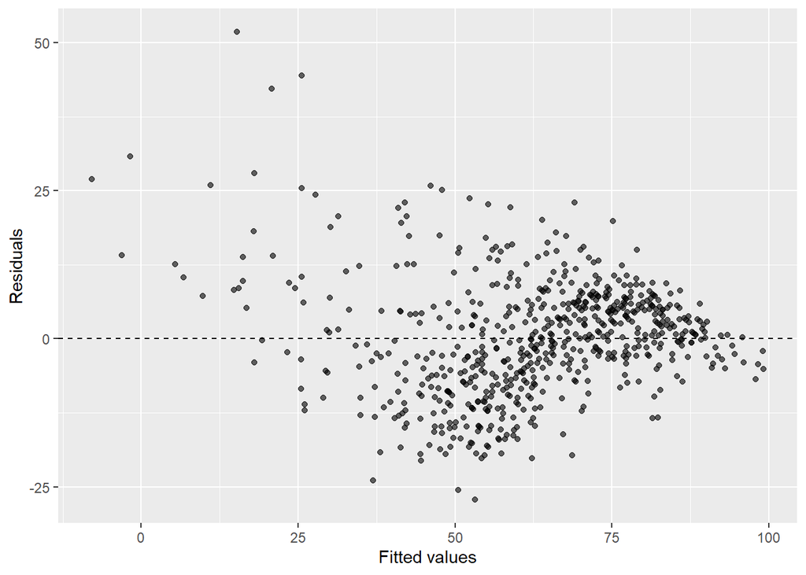

```r
ggplot(data = model_aug, aes(x = .fitted, y = .resid)) +
  geom_point(alpha = 0.6) +
  geom_hline(yintercept = 0, linetype = "dashed") +
  labs(x = "Fitted values", y = "Residuals")
```

We can see that there is linearity however, lesser the audience score the more the variability. This could indicate the presense of factors that has not been provided in the dataset.

Normality: To check this condition, we can look at a histogram of residuals

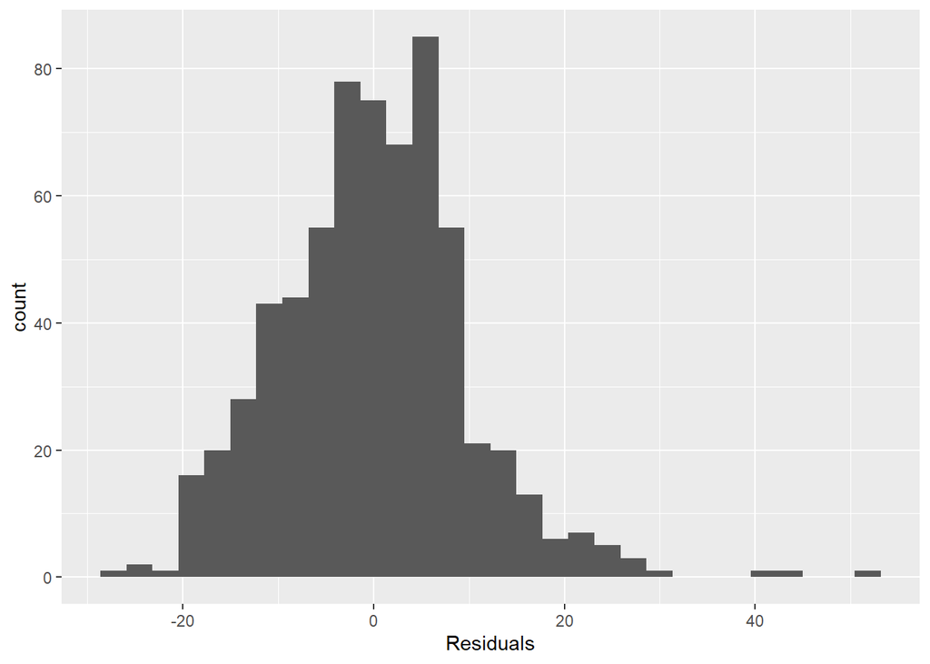

```r
ggplot(data = model_aug, aes(x = .resid)) +
  geom_histogram() +
  xlab("Residuals")
```

Taking a look at the normal probability plot of the residuals:

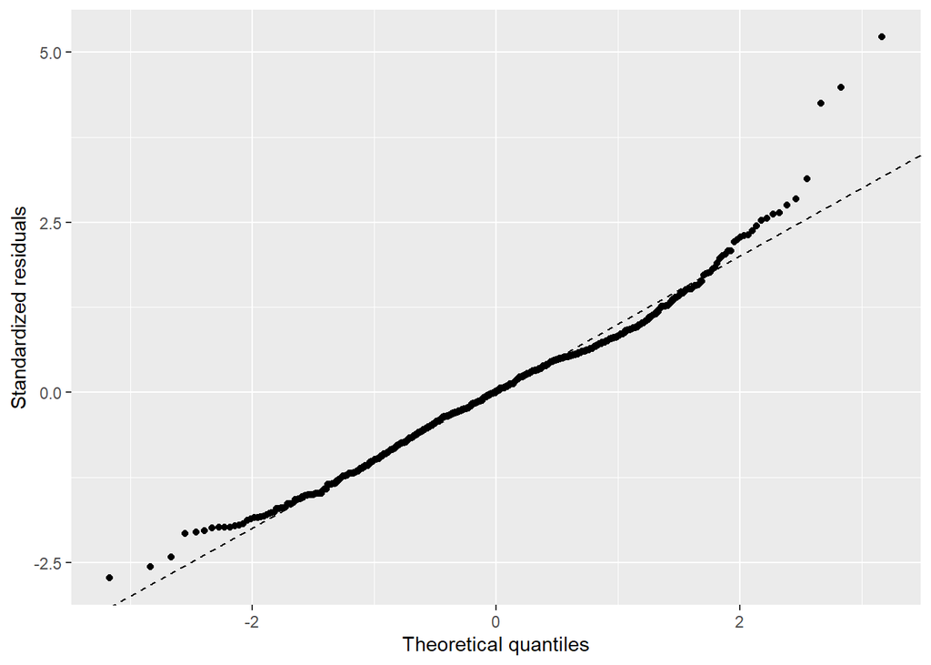

```r
ggplot(model_aug) +
  geom_qq(aes(sample = .std.resid)) +
  geom_abline(slope = 1, intercept = 0, linetype = "dashed") +
  labs(x = "Theoretical quantiles", y = "Standardized residuals")
```

We can see that the plot is fairly straight except for the ends which we choose to ignore for this particular case. * * *

## Part 5: Prediction

For this section we will choose a movie from 2016 to predict the audience score. We will choose La La Land to do our prediction. All the data is taken from Imdb as well as Rotten Tomatoes. Let us run the prediction as well as form the Credible Interval at 95% and have a look at the outcome.

```r
topred<-data.frame(feature_film="Yes",drama="Yes",runtime=12, thtr_rel_year=2016,critics_score=91,top200_box='yes',oscar_season="Yes",summer_season="No",imdb_rating=8,imdb_num_votes=472791,best_pic_nom="yes" ,best_pic_win="no" ,best_actor_win="no" ,best_actress_win="yes" ,best_dir_win="yes" ,top200_box="yes" )
```

```r
BPM_audience_score <- predict(bma_audience_score, estimator = "BPM",topred, se.fit = TRUE)
confint(BPM_audience_score)
```

```
##          2.5%    97.5%     pred
## [1,] 60.90845 118.3825 89.64547
## attr(,"Probability")
## [1] 0.95
## attr(,"class")
## [1] "confint.bas"
```